# ETL Ecommerce

Jairo Lopes

# Projeto ecommerce

### Resumo

Uma empresa de comercio eletrônico que vende roupas online, mas também tem sessões de consultoria em estilo e vestuário. Os clientes entram na loja, têm sessões/reuniões com um estilista pessoal, então podem ir para casa e encomendarem em um aplicativo móvel ou site para a roupa que desejam.

A empresa está tentando decidir se deve concentrar seus esforços em aplicativos móveis ou em seu site.

Será feita uma análise exploratória para extrair informações relevantes para responder em quais midias investir para maior faturamento: app ou site.

# ____________________________________________________________________________

### Visão geral do dataset

```r
df %>% head %>% knitr::kable()
```

| avatar | duracao consulta estilista | tempo online app | tempo online site | tempo de membro | valor anual gasto | Email |
| --- | --- | --- | --- | --- | --- | --- |
| Violet | 34.49727 | 12.65565 | 39.57767 | 4.082621 | 587.9511 | mstephenson@fernandez.com |
| DarkGreen | 31.92627 | 11.10946 | 37.26896 | 2.664034 | 392.2049 | hduke@hotmail.com |
| Bisque | 33.00091 | 11.33028 | 37.11060 | 4.104543 | 487.5475 | pallen@yahoo.com |
| SaddleBrown | 34.30556 | 13.71751 | 36.72128 | 3.120179 | 581.8523 | riverarebecca@gmail.com |
| MediumAquaMarine | 33.33067 | 12.79519 | 37.53665 | 4.446308 | 599.4061 | mstephens@davidson-herman.com |
| FloralWhite | 33.87104 | 12.02693 | 34.47688 | 5.493507 | 637.1024 | alvareznancy@lucas.biz |

# ____________________________________________________________________________

### Tendo uma visão geral das variáveis que possam ter fortes correlações

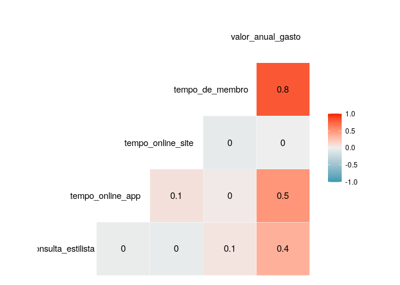

```r
ggcorr(df[,c(-1, -7)], label = T, hjust=0.75)
```

# ____________________________________________________________________________

## Analisando as correlações detectadas de forma mais detalhada

# ____________________________________________________________________________

### Visualizando a distribuição entre valor gasto pelo cliente por ano pelo tempo ele é cliente

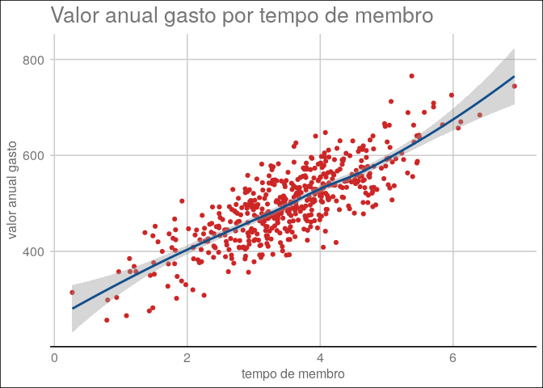

```r
ggplot(df, aes(x=`tempo de membro`, y=`valor anual gasto`)) + geom_point(color="firebrick3") +
theme_gdocs() + labs(title = "Valor anual gasto por tempo de membro") + geom_smooth(color="dodgerblue4")
```

**OBS:** É notável que quanto mais antigo o cliente for, mais ele consome por ano

# ____________________________________________________________________________

### Visualizando a correlação entre valor gasto pelo cliente por ano, e quanto tempo em media ele passa olhando o aplicativo

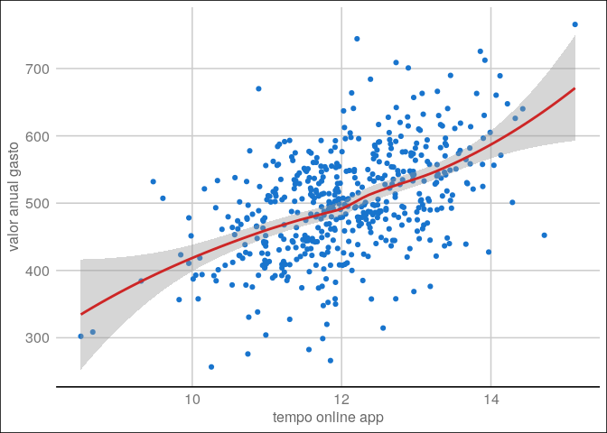

```r
ggplot(df, aes(x=`tempo online app`, y=`valor anual gasto`)) + geom_point(color="dodgerblue3") + geom_smooth(color="firebrick3") + theme_gdocs()
```

**OBS:** Podemos ver que existe uma certa correlação no tempo que os clientes passam no aplicativo com o quanto ele gasta

# ____________________________________________________________________________

### Verificando o quanto que as consultas com o estilista influenciam no consumo dos clientes

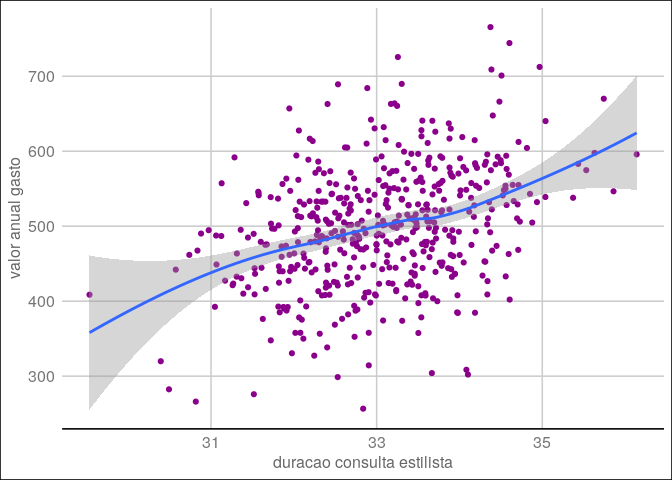

```r
ggplot(df, aes(x=`duracao consulta estilista`, y=`valor anual gasto`)) + geom_point(color="magenta4") + theme_gdocs() +
geom_smooth()
```

**OBS:** Apesar de não ser uma correlação forte, podemos ver que há uma certa influência do tempo que o cliente consulta o estilista em relação ao consumo anual.

# ____________________________________________________________________________

# Conclusão

# ____________________________________________________________________________